# Loan Data from Prosper

## By: Maryam Raafat

## Investigation Overview

> In this investigation, I wanted to look at the characteristics of loans that could be used to predict their borrower APR. The main focus was on the original loan amount, borrower's Prosper rating, loan term, borrower's stated monthly income, Employment Status , Term and Occupation.

## Dataset Overview

> The dataset contains 83982 loans with 21 features (including LoanOriginalAmount, BorrowerAPR, StatedMonthlyIncome, ProsperRating (Alpha), EmploymentStatus and many others)

```python
# import all packages and set plots to be embedded inline
import numpy as np
import pandas as pd
import matplotlib.pyplot as plt
import seaborn as sb

%matplotlib inline

# suppress warnings from final output
import warnings
warnings.simplefilter("ignore")
```

```python
df_loan = pd.read_csv('dfLoan_clean.csv');
```

## Distribution of loans listed year, month and day of the month wise

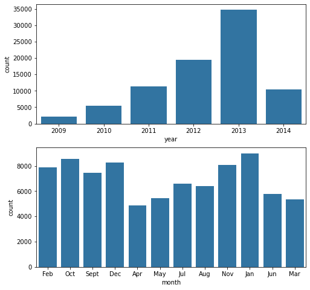

```python
fig, ax = plt.subplots(nrows=2, figsize = [8,8]);
default_color = sb.color_palette()[0];
sb.countplot(data = df_loan, x = 'year', color = default_color, ax = ax[0]);
sb.countplot(data = df_loan, x = 'month', color = default_color, ax = ax[1]);
```

## Distribution of Borrower APR

> The distribution of APR looks multimodal. A small peak centered at 0.1, a large peak centered at 0.2. There is also a small peak centered 0.3. Additionally, there is a very shape peak between 0.35 and 0.36. Only very few loans have APR greater than 0.43.

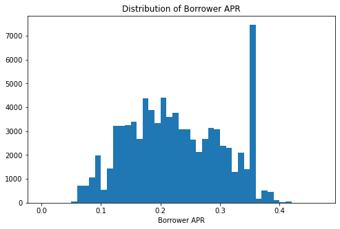

```python
bins = np.arange(0, df_loan.BorrowerAPR.max()+0.05, 0.01);
plt.figure(figsize=[8, 5]);
plt.hist(data = df_loan, x = 'BorrowerAPR', bins = bins);
plt.xlabel('Borrower APR');
plt.title('Distribution of Borrower APR');
```

## Distribution of DebtToIncomeRatio

> Distribution has unimodal peak around 0.2 with unusual peak around 0.25 which indicates most people prefer 1:4 ratio of debt to Income which is a good thing.

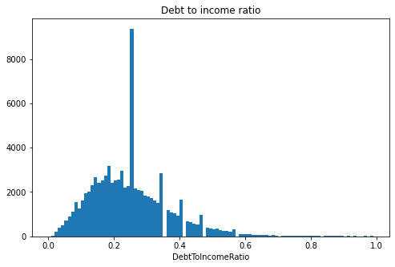

```python
bins = np.arange(0,1, 0.01);
plt.figure(figsize=[8, 5]);
plt.hist(data = df_loan, x = 'DebtToIncomeRatio', bins = bins);
plt.xlabel('DebtToIncomeRatio');
plt.title("Debt to income ratio")
```

## Borrower APR vs. Loan Amount

> At different size of the loan amount, the APR has a large range, but the range of APR decrease with the increase of loan amount. Overall, the borrower APR decrease with increase of loan amount

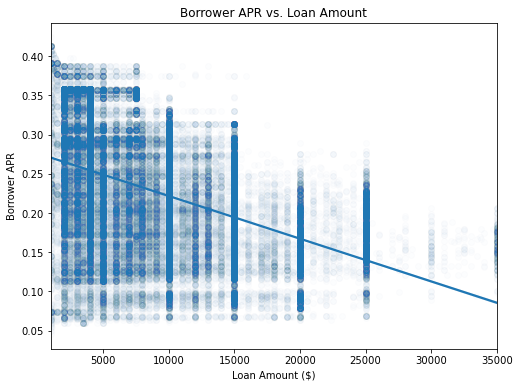

```python
plt.figure(figsize = [8, 6]);
sb.regplot(data = df_loan, x = 'LoanOriginalAmount', y = 'BorrowerAPR', scatter_kws={'alpha':0.01});
plt.xlabel('Loan Amount ($)');
plt.ylabel('Borrower APR');
plt.title('Borrower APR vs. Loan Amount');
```

## Borrower APR vs. Prosper Rating

> The borrower APR decreases with the increasingly better rating. Borrowers with the best Prosper ratings have the lowest APR. It means that the Prosper rating has a strong effect on borrower APR.

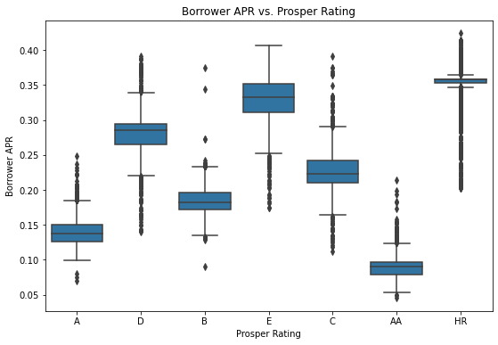

```python
plt.figure(figsize=[9,6]);
default_color = sb.color_palette()[0];
sb.boxplot(data=df_loan, x='ProsperRating (Alpha)', y='BorrowerAPR', color=default_color);
plt.xlabel('Prosper Rating');
plt.ylabel('Borrower APR');
plt.title('Borrower APR vs. Prosper Rating');
```

## Borrower APR vs Occupation

> The borrower APR changes with the occupation,Interestingly with student in technical schools having least and college sophomores having highest average rating.

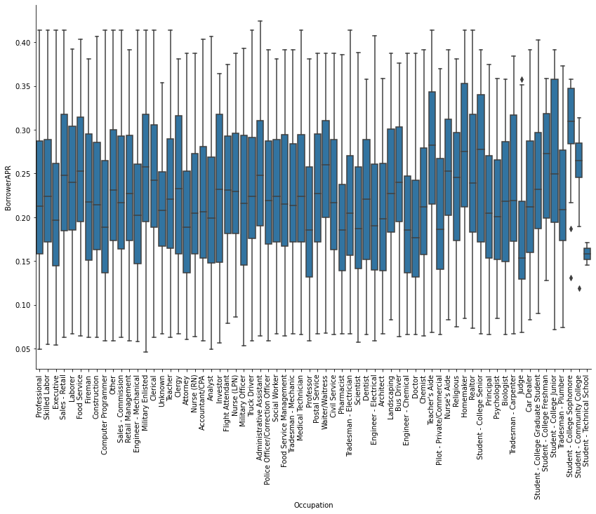

```python
def boxgrid(x, y, **kwargs):
    """ Quick hack for creating box plots with seaborn's PairGrid. """
    default_color = sb.color_palette()[0]
    sb.boxplot(x, y, color = default_color)

plt.figure(figsize = [10, 10]);
g = sb.PairGrid(data = df_loan, y_vars = ['BorrowerAPR'],
                x_vars = ['Occupation'] , height = 8, aspect = 1.5);
g.map(boxgrid);
plt.xticks(rotation=90);
```

## Prosper Rating Effect on Relationship between APR and Loan Amount

> The loan amount increases with better rating. The borrower APR decreases with better rating. Interestingly, the relationship between borrower APR and loan amount turns from negative to slightly positive when the Prosper ratings are increased from HR to A or better. This is may because people with A or AA ratings tend to borrow more money, increasting APR could prevent them borrow even more and maximize the profit. But people with lower ratings tend to borrow less money, decreasing APR could encourage them to borrow more.

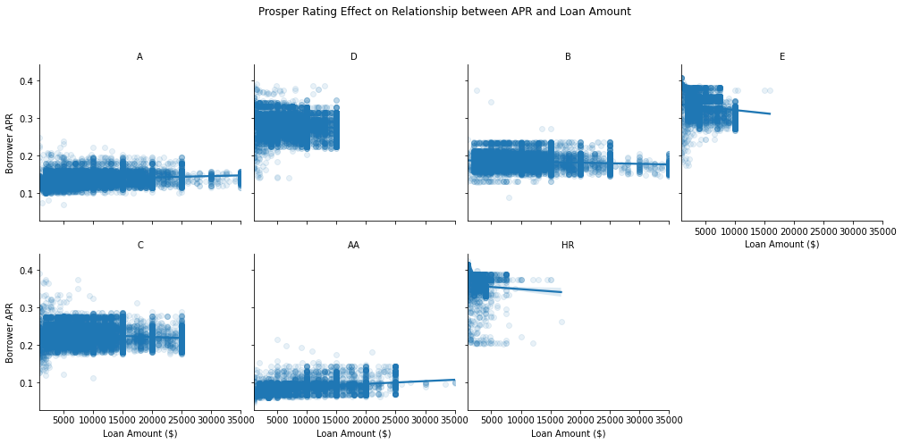

```python
g=sb.FacetGrid(data=df_loan,col='ProsperRating (Alpha)', height=3.5, col_wrap=4);
g.map(sb.regplot, 'LoanOriginalAmount', 'BorrowerAPR', x_jitter=0.04, scatter_kws={'alpha':0.1});
g.set_titles('{col_name}');
g.add_legend();
g.set_xlabels('Loan Amount ($)');
g.set_ylabels('Borrower APR');
plt.suptitle('Prosper Rating Effect on Relationship between APR and Loan Amount');
plt.subplots_adjust(top=0.85);
```

## StatedMonthlyIncome and LoanOriginalAmount by Rating and Term

> StatedMonthlyIncome and LoanOriginalAmount change with the increase in the borrow term and ratings on an average.

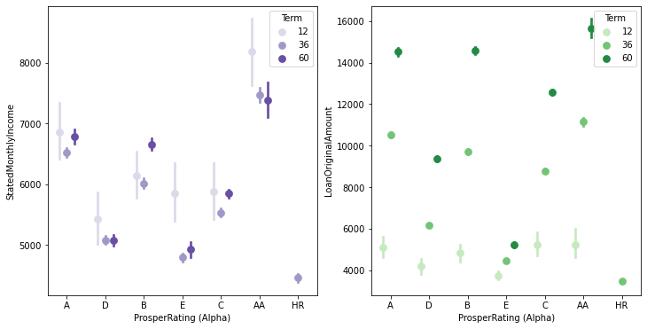

```python
fig, ax = plt.subplots(ncols=2, figsize=[12,6]);
sb.pointplot(data = df_loan, x = 'ProsperRating (Alpha)', y = 'StatedMonthlyIncome', hue = 'Term',
           palette = 'Purples', linestyles = '', dodge = 0.4, ax=ax[0]);
sb.pointplot(data = df_loan, x = 'ProsperRating (Alpha)', y = 'LoanOriginalAmount', hue = 'Term',
           palette = 'Greens', linestyles = '', dodge = 0.4, ax=ax[1]);
```

## Borrower APR by Rating and Term

> Interestingly, the borrower APR decrease with the increase of borrow term for people with HR-C raings. But for people with B-AA ratings, the APR increase with the increase of borrow term.

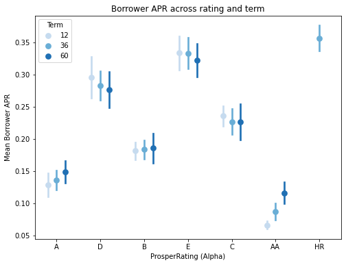

```python
fig = plt.figure(figsize = [8,6]);
ax = sb.pointplot(data = df_loan, x = 'ProsperRating (Alpha)', y = 'BorrowerAPR', hue = 'Term',
           palette = 'Blues', linestyles = '', dodge = 0.4, ci='sd');
plt.title('Borrower APR across rating and term');
plt.ylabel('Mean Borrower APR');
ax.set_yticklabels([],minor = True);
```

## Summary

> The distribution of APR looks multimodal. A small peak centered at 0.1, a large peak centered at 0.2. There is also a small peak centered 0.3. Additionally, there is a very shape peak between 0.35 and 0.36. Only very few loans have APR greater than 0.43.

> Distribution has unimodal peak around 0.2 with unusual peak around 0.25 which indicates most people prefer 1:4 ratio of debt to Income which is a good thing.

> At different size of the loan amount, the APR has a large range, but the range of APR decrease with the increase of loan amount. Overall, the borrower APR decrease with increase of loan amount

> The borrower APR decreases with the increasingly better rating. Borrowers with the best Prosper ratings have the lowest APR. It means that the Prosper rating has a strong effect on borrower APR.

> The borrower APR changes with the occupation,Interestingly with student in technical schools having least and college sophomores having highest average rating.

> Interestingly, the borrower APR decrease with the increase of borrow term for people with HR-C raings. But for people with B-AA ratings, the APR increase with the increase of borrow term.